# Przetwarzanie Danych Środowiskowych - Analiza danych jakości powietrza z bazy danych GIOS i danych meteo z bazy ISD NOAA

26 maj, 2022

**Uczelnia:** *Akademia Górniczo-Hutnicza im. Stanisława Staszica w Krakowie*

**Wydział:** *Wydział Geodezji Górniczej i Inżynierii Środowiska*

**Kierunek:** *Geoinformacja*

**Rok:** *drugi*

**Semestr:** *czwarty*

**Przedmiot:** *Przetwarzanie Danych Środowiskowych*

**Prowadzacy:** *dr inż. Mateusz Rzeszutek*

**Autorzy:**

- Tymoteusz Maj, 401370, tymoteuszmaj@student.agh.edu.pl
- Hubert Dębowski, 407955, hdebowski@student.agh.edu.pl

[figure not shown]

# 1. Cel

Celem wykonania przedmiotowego projektu jest zapoznanie się studentów Geoinformacji (Informatyki Geoprzestrzennej) o przetwarzaniu danych jakości powietrza z danych **GIOS** (które pobraliśmy przy skorzystaniu z pakietu **giosimport**), oraz sprawdzenie ich korealacji z zjawiskami pogodowymi z bazdy **ISD NOAA**, w celu prognozowania zanieczyszczeń w najbliższej przyszłości. Aby prawidłowo wykonac zlecone nam zadanie musielismy zapoznac sie z formatem danych, poznać narzędzia które ułatwią nam pracę oraz ich przetwarzanie. Musieliśmy dokonać analizy statystycznej danych aby okreslic panujące trendy oraz w celu zauważenia zależności między poszczególnymi danymi. Ostatnim aspektem naszej pracy, było napisanie sprawozdania technicznego z wykonanengo przez nas ćwiczenia przy pomocy RMarkdown, w celu udokumentowania naszej pracy w języku R.

# 2. Technologie wykorzystane w analizie

## 2.1. R (język programowania)

**R** - interpretowany jezyk programowania oraz srodowisko do obliczen statystycznych. Stosowany jest w analizie szeroko rozumianych danych środowiskowych i przestrzennych oraz ich wizualizacji. Podobny jest do języka i środowiska S stworzonego w Bell Laboratories przez Johna Chambersa i jego współpracowników. R jako implementacja języka S została stworzona przez Roberta Gentlemana i Rossa Ihakę na uniwersytecie w Auckland. Nadaje się on świetnie do interaktywnej pracy z danymi, ponieważ połączono w nim wybrane cechy języków funkcyjnych oraz obiektowych.

*Źródlo*

## 2.2. R Markdown

**R Markdown** - jest formatem pliku stworzonym do sporzadzania dynamicznych dokumentow z wykorzystaniem R. Plik typu Markdown jest pisany w specyficzny dla siebie sposob, który zaklada bardzo latwa edycje tekstu oraz implementowanie w nim fragmentow kodu (chunki zawierajace kod z poleceniami w jezyku R). R Markdown jest bardzo wygodna metoda formatowania plikow HTML, PDF i dokumentow MS Word.

[*Źródlo*](https://rmarkdown.rstudio.com/articles_intro.html)

## 2.3. giosimport

Celem pakietu giosimport jest pobieranie i wczytywanie danych z Portal Jakości Powietrza GIOŚ. Teoretycznie dane te mają jednorodną strukturę i ich wczytanie powinno być dość proste. Niestety w tych danych wielokrotnie pojawiają się różnego rodzaju nieścisłości, które uniemożliwiały stosowanie prostych i przejrzystych rozwiązań. Kod projektu stawał się bardzo długi, a spora jego część skupiała się na pozyskaniu danych i przekonwertowaniu ich do wygodnej formy pracy.

Funkcje zawarte w pakiecie tworzą plikową bazę danych na dysku lokalnym. Cała baza danych może zajmować prawie 700 MB. Istnieje możliwość pobierania tylko wybranych części plikowej bazy danych. W tym przypadku dane są pobierane dla każdego roku oddzielnie. Dostępne dane historyczne nie są aktualizowane, więc wystarczy je pobrać tylko raz. Warto umieścić je w odpowiedniej lokalizacji, by nie powielać pobierania danych.

[*Źródlo - Zadanie Projektowe*](https://github.com/mrzeszut/giosimporte)

## 2.4 Baza ISD NOAA

Baza [ISD NOAA](https://www.ncdc.noaa.gov/isd) (Integrated Surface Database of the National Oceanic and Atmosferic Administration) jest obecnie jednym z największych zbiorów bezpłatnie udostępnianych meteorologicznych danych pomiarowych. Zawiera ona obserwacje uśredniane w czasie jednej godziny dla 12826 naziemnych punktów pomiarowych.

Pomiary meteorologiczne w formacie ASCII udostępniane są bezpłatnie przez serwer FTP, jednak pobieranie ich w sposób bezpośredni jest żmudne i pracochłonne. Format w jakim są przechowywane dane wymaga dodatkowego przetworzenia, aby możliwa była ich swobodna analiza.

Dane pomiarowe z bazy ISD NOAA przechowywane są za pomocą znaków ASCII w plikach formatu ISH (Integrated Surface Hourly - Compressed Archive). Informacje dotyczące tego, jakie zmienne i w jakich jednostkach są udostępniane znajdują się w szczegółowej dokumentacji formatu. Wartość każdej z dostępnych zmiennych zajmuje określone pozycje w rekordzie pliku, tak więc bez znajomości jego dokładnej struktury każda linijka jest tylko zakodowanym rzędem cyfr i liter. Poza 34 zmiennymi, które są obligatoryjne, czasem znajdziemy również dodatkowe informacje w pliku. Wśród najważniejszych zmiennych możemy wyróżnić wartości wybranych pomiarów meteorologicznych, informacje dotyczące stacji i źródła obserwacji, a także wyniki testów jakości dla poszczególnych serii pomiarowych.

[*Źródlo - Zadanie Projektowe*](https://rstudio-pubs-static.s3.amazonaws.com/579343_ee4609d7ebca4217a0530fdc7eadad9c.html#wprowadzenie)

## 2.5. Portal Jakość Powietrza GIOŚ

Inspekcja Ochrony Środowiska jest powołana do kontroli przestrzegania przepisów o ochronie środowiska oraz badania i oceny stanu środowiska. W skład Inspekcji wchodzą: Główny Inspektorat Ochrony Środowiska (GIOŚ) oraz 16 wojewódzkich inspektoratów ochrony środowiska. Działalnością Inspekcji kieruje Główny Inspektor Ochrony Środowiska

Monitoring jakości powietrza obejmuje zadania związane z badaniem i oceną stanu zanieczyszczenia powietrza, w tym pomiary i oceny jakości powietrza w strefach, monitoring tła miejskiego pod kątem WWA, pomiary stanu zanieczyszczenia powietrza pyłem PM2,5 dla potrzeb monitorowania procesu osiągania krajowego celu redukcji narażenia, pomiary stanu zanieczyszczenia powietrza metalami ciężkimi i WWA oraz rtęcią w stanie gazowym na stacjach monitoringu tła regionalnego, pomiary składu chemicznego pyłu PM2,5, monitoring prekursorów ozonu; programy badawcze dotyczące zjawisk globalnych i kontynentalnych wynikające z podpisanych przez Polskę konwencji ekologicznych.

Celem funkcjonowania monitoringu jakości powietrza, zgodnie z art. 23 ust. 11 pkt 1 ustawy z dnia 20 lipca 1991 r. o Inspekcji Ochrony Środowiska, jest uzyskiwanie informacji i danych dotyczących poziomów substancji w otaczającym powietrzu oraz wyników analiz i ocen w zakresie przestrzegania norm jakości powietrza.

[*Źródlo*](https://powietrze.gios.gov.pl/pjp/content/about_us)

## 2.6. Metody pomiaru zanieczyszczenia powietrza

Inspekcja Ochrony Środowiska bada zawartość pyłu zawieszonego PM10 i PM2,5 w powietrzu stosując dwie uzupełniające się metody:

- metodę grawimetryczną (referencyjną), która jest uznana i stosowana na świecie jako najbardziej precyzyjna metoda pomiaru;
- metodę automatyczną, posiadającą wykazaną równoważność do metody referencyjnej.

### 2.6.1. Metoda grawimetryczna

W tej metodzie używa się tzw. poborników pyłowych, specjalnych urządzeń, do których zasysane jest powietrze atmosferyczne. Co dwa tygodnie do pobornika zakłada się 14 jednorazowych filtrów, które urządzenie zmienia automatycznie co 24 godziny. Każdy filtr posiada swój niepowtarzalny numer identyfikacyjny.

Filtry czyste, przed założeniem do pobornika są kondycjonowane i ważone w laboratorium, umieszczane w specjalnych pojemnikach do transportu, a następnie transportowane na stację pomiarową i umieszczane w poborniku. Po 14 dniach wszystkie filtry są wyjmowane, umieszczane w specjalnych pojemnikach do transportu i przewożone do laboratorium. W laboratorium filtry są kondycjonowane i ważone po raz drugi, już jako filtry po tzw. ekspozycji. Z różnic mas przed i po ekspozycji filtra, odniesionych do objętości przepływu powietrza w poborniku, wyliczane są stężenia pyłów. Stężania te podawane są w mikrogramach na metr sześcienny [µg/m3].

Zaletą tej metody pomiarowej jest jej bardzo wysoka dokładność. Jedyną jej wadą jest czas potrzebny na uzyskanie wyników, który wynosi ok. 3 tygodni.

Taką metodą w Polsce, Europie, czy Stanach Zjednoczonych, mierzy się stężenia pyłu zawieszonego. Filtry uzyskane z poborników pyłowych wykorzystywane są również do oznaczania metali ciężkichi wielopierścieniowych węglowodorów aromatycznych, w tym benzo(a)pirenu.

Obecnie w Polsce pomiary metodą grawimetryczną są prowadzone na ok. 180 stanowiskach pyłu PM10 i ok. 70 stanowiskach pyłu PM2,5.

### 2.6.2. Metoda automatycza

Aby urządzenie do automatycznych pomiarów pyłu zawieszonego dopuszczone zostało do pomiarów, które wykorzystywane będą do celów oceny jakości powietrza, stosowana przez nie metoda pomiarowa musi zostać uznana za metodę równoważną do metodyki referencyjnej. W takim wypadku należy wykazać, iż urządzenie spełnia wymagania równoważności, a wyniki takich badań muszą zostać przedstawione Komisji Europejskiej i zaakceptowane przez nią.

Do pomiarów wykonywanych w ramach Państwowego Monitoringu Środowiska stosuje się mierniki automatyczne, które posiadają certyfikaty potwierdzające ich równoważność z metodą referencyjną. Mierniki te na bieżąco mierzą stężenia pyłu, co umożliwia pokazywanie wyników tych pomiarów w trybie „on-line” na portalach inspekcji ochrony środowiska (GIOŚ i WIOŚ) i w aplikacji GIOŚ „Jakość powietrza w Polsce”. Dane te są aktualizowane co godzinę i, w celu porównania z poziomem dopuszczalnym, przeliczane na wartości średniodobowe.

Obecnie w Polsce pomiary metodą automatyczną są prowadzone na ok. 135 stanowiskach pyłu PM10 i 45 stanowiskach pyłu PM2,5.

Dane pozyskiwane z mierników automatycznych, które są widoczne „on-line” na portalach i w aplikacji powietrznej GIOŚ, określane są jako dane „surowe”, czyli takie, które nie zostały poddane weryfikacji.

*[Źródlo]https://powietrze.gios.gov.pl/pjp/content/show/1000919)*

# 3. Opis wybranej lokalizacji stacji

W celu wykonania przedmiotowego ćwiczenia postanowiliśmy skorzystać z stacji znajdujących się w mieście Radom (GIOS) i jego okolicach (ISD NOAA). Podjeliśmy taką decyzję gdyż jest to miasto rodzinne dla jednego z nas, dzięki czemu ta analiza dodatkowo może być dla nas ciekawa.

Radom - miasto na prawach powiatu znjadujące się w centralno-wschodniej cześci kraju. Położone jest nad rzeką Mleczną. Pomimo administracyjnej przynależności do województwa mazowieckiego pod względem historycznym, kulturowym i etnograficznym Radom wraz ze swoim regionem stanowią integralną część Małopolski.

Według projektu ESPON Radom zalicza się do grona dużych miast o znaczeniu krajowym lub międzynarodowym.

Miasto jest również organizatorem międzynarodowych pokazów lotniczych Radom Air Show. Międzynarodowy Festiwal Gombrowiczowski i Radomski Festiwal Jazzowy są dziś kulturową wizytówką miasta.

[*Źródlo*](https://pl.wikipedia.org/wiki/Radom)

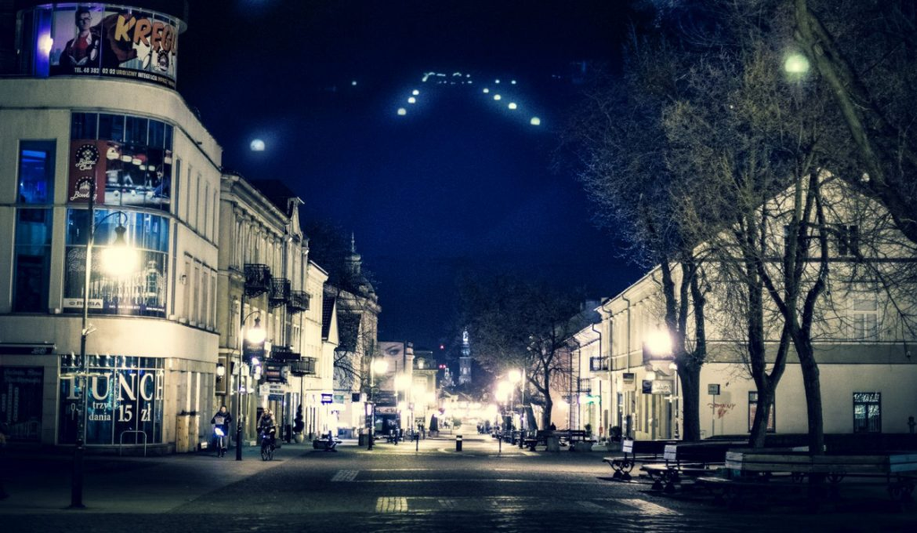

[*Źródlo*](https://modanamazowsze.pl/radom-art-night/)

# 4. Pozyskanie danych

Pozyskanie danych do wykonania projektowego ćwiczenia rozpoczęliśmy od okreslenia katalogu dostepu do którego przedmiotowe dane mają zostać zapisane. Umożliwi nam to w przyszłości opanowanie tego gdzie nasze dane są zapisywane na naszym urządzeniu. Dzięki temu w każdej chwili będziemy mieć do nich łatwy dostęp.

Katalog dostępu ustawiliśmy za pomocą poniższego polecenia.

```r
kat_dost <- "D:/Biblioteka rzeczy na studia/IV Semestr/Przetwarzanie danych środowiskowych/Mateusz Rzeszutek, dr inż/Projekt/Dane"
```

Następnie dzięki zapisaniu ścieżki zapisu dla naszych plików mogliśmy przystąpić do pobierania przedmiotowych danych dla miasta Radom. Jednak aby prawidłowo określić jego położenie oraz dostępność stacji przyjrzyjmy się poniższej mapie:

```r
getMeta(site = "", lat = 51.403611, lon = 21.156667,end.year = "current", plot = T, returnMap = T )
```

[interactive chart not shown]

Dzięki niej możemy zauważyć że najbliższa stacja meteo względem naszego miasta znajduje się w miejscowości **Kozienice**, i to właśnie z stacji położonej w tej lokalizacji będziemy korzystać wykonując przedmiotowe ćwiczenie. Uważamy ze dystans dzielący te stacje jest na tyle nie wielki, że żaden błąd poimiarowy nie powinien wystąpić z tytułu zastosowania tej stacji.

## 4.1. Pozyskanie danych meteo

Możemy z łatwością odczytać kod stacji meteo : 124880-99999. To właśnie przy jego pomocy pozyskamy teraz dane meteo dla tej stacji.

```r
dane <- importNOAA(code = "124880-99999", year = 2000:2019)
```

```r
mapa <- getMeta(site= "KOZIENICE", end.year="current", returnMap=TRUE)
```

Należy pamiętać że pozyskane dane znajdują się w formacie UTF+0 (dane GIOS UTF+1) - na to zwrócimy uwagę w dalszej cześci naszej analizy.

Aby nasze dane mogły zostać z sobą połączone a co za tym idzie żeby ich analiza mogła odbywać się jednocześnie musieliśmy te dane “dostosować” względem siebie. W celu uniknięcie błędu podczas połączenia z sobą tych danych, skorzystaliśmy z poniższej serii poleceń. Postanowiliśmy do przedmiotowych danych “dodać” 1h w celu zrównania ich z danymi na temat jakości powietrza.

```r
kozienice <- dane
kozienice$date <- kozienice$date+3600
kozienice <-kozienice[c(3,7:14)]
```

Pozyskane dane zostały zapisane jako zmienna w środowisku R.

## 4.2. Pozyskanie danych GIOS

Proces pozyskania danych dla stacji GIOS, znajdujących się na terenie wybranego przez nas Radomia rozpoczęliśmy od pobrania na dysk (do określonego wcześniej katalogu dostępu) oraz wczytania metadanych dotyczących stacji jakości powietrza do środowiska programu R.

```r
meta <- gios_metadane(type = "stacje",
                      download = F,      #T za pierwsztm razem
                      path = kat_dost,
                      mode = "wb")
```

Udało nam się do zleconego katalogu pobrać plik binarny, który następnie został wczytany do danych metadane, z których będziemy korzystać w późniejszym etapie naszej pracy.

Aby odczytać podstawowe informacje o pobranych przez nas danych posłużymy się ramką danych, dzięki niej z łatwością będziemy mogli odczytać informacje o stacjach, takie jak: kod pocztowy, typ, rodzaj oraz lokalizację.

```r
dplyr::glimpse(meta)
```

```
## Rows: 1,055
## Columns: 15
## $ nr                 <dbl> 1, 2, 3, 4, 5, 6, 7, 8, 9, 10, 11, 12, 13, 14, 15, …
## $ kod.stacji         <chr> "DsBialka", "DsBielGrot", "DsBogatFrancMOB", "DsBog…
## $ kod.miedzynarodowy <chr> NA, NA, "PL0602A", "PL0315A", "PL0576A", "PL0658A",…
## $ nazwa.stacji       <chr> "Białka", "Bielawa - ul. Grota Roweckiego", "Bogaty…
## $ stary.kod.stacji   <chr> "DsBialka", "DsBielGrot", "DsBogatMob", "DsBogChop"…
## $ data.uruchomienia  <date> 1990-01-03, 1994-01-02, 2015-01-01, 1996-01-01, 20…
## $ data.zamkniecia    <date> 2005-12-31, 2003-12-31, 2015-12-31, 2013-12-31, 20…
## $ typ.stacji         <chr> "przemysłowa", "tło", "tło", "przemysłowa", "przemy…
## $ typ.obszaru        <chr> "podmiejski", "miejski", "miejski", "miejski", "mie…
## $ rodzaj.stacji      <chr> "kontenerowa stacjonarna", "w budynku", "mobilna", …
## $ wojewodztwo        <chr> "DOLNOŚLĄSKIE", "DOLNOŚLĄSKIE", "DOLNOŚLĄSKIE", "DO…
## $ miejscowosc        <chr> "Białka", "Bielawa", "Bogatynia", "Bogatynia", "Bog…
## $ adres              <chr> NA, "ul. Grota Roweckiego 6", "ul. Francuska/Kręta"…
## $ lat                <dbl> 51.19778, 50.68251, 50.94100, 50.90586, 50.94324, 5…
## $ lon                <dbl> 16.11739, 16.61735, 14.91679, 14.96717, 14.91333, 1…
```

W celu lepszego zobrazowania rozmieszczenai stacji skorzystaliśmy z funkcji gios_vis, która generuje interaktywną mapę lokalizacji stacji. Każda stacja ma przypisaną etykietę w postaci kodu stacji.

```r
gios_vis(data = meta %>% filter(is.na(data.zamkniecia))) # tylko aktywne stacje
```

[interactive chart not shown]

Po odpowiednim przybliżeniu możemy zauważyć że wybrane przez nas miejsce posiada na swoim terenie trzy stacje tła miejskiego, znajdująca się blisko stacja meteo upewnia nas tylko w przekonaniu, że wybrana przez nas lokalizacja jest odpowiednia do przeprowadzenia analizy.

Jeżeli wiemy że przedmiotowe stacje znajdują się na terenie miasta przejdźmy teraz do pobrania interesujących nas danych na temat wybranych stacji pomiarowych. Dane te są istostne dla nas, gdyż zawierają informacje o tym jakie substancje są mierzone na każdej z stacji.

```r
stanowiska <- gios_metadane(type = "stanowiska",
                            download = T,
                            path = kat_dost,
                            mode = "wb")
```

Aby uniknąć problemu wiążącego się z wyodrębnianiem danych, postanowiliśmy je wyodrębnić już na tym etapie naszej pracy, w tym celu skorzystaliśmy z poniższej serii poleceń:

```r
stanowiska_mazowieckie <- data.frame(stanowiska %>%
                                       filter(is.na(data.zamkniecia)) %>%
                                       filter(wojewodztwo == "MAZOWIECKIE"))
```

Następnie posiadając wyfilrowane dane dla całego województwa mazowieckiego, wyodrębniliśmy z nich dane dotyczące interesującego nas miasta - Radomia.

```r
stanowiska_radom <- stanowiska_mazowieckie %>% filter(nazwa.strefy == "miasto Radom")
```

Następnym krokiem naszej analizy który postanowiliśmy wykonać było ściągniecię statystyk podstawowych za pomocą funkcji gios_metadane(), W pliku tym znajdują się wszystkie niezbędne miary statystyczne potrzebne nam w późniejszym etapie do przeprowadzenia oceny jakości powietrza w wybranej przez nas stacji. Aby tego dokonać skorzystaliśy z poniższej listy poleceń:

```r
statystyki_podstawowe <- gios_metadane(type = "statystyki",
                           download = F,
                           path = kat_dost,
                           mode = "wb")
```

Funkcję gios_download zastosowaliśmy aby pobrać całą plikową bazę danych przy pomocy jednego polecenia. Zastosowane polecenie pozwoliło pobrać nam archiwum plików z Banku danych lokalnych portalu <powietrze.gios.gov.pl>.

Głównymi argumentami funkcji są url oraz rok. Wartości tych argumentów przedstawia poniższa tabela, która jest zapisana w pakiecie jako obiekt zrodlo.

```r
zrodlo %>% knitr::kable()
```

| link | rok |
| --- | --- |
| http://powietrze.gios.gov.pl/pjp/archives/downloadFile/223 | 2000 |
| http://powietrze.gios.gov.pl/pjp/archives/downloadFile/224 | 2001 |
| http://powietrze.gios.gov.pl/pjp/archives/downloadFile/225 | 2002 |
| http://powietrze.gios.gov.pl/pjp/archives/downloadFile/226 | 2003 |
| http://powietrze.gios.gov.pl/pjp/archives/downloadFile/202 | 2004 |
| http://powietrze.gios.gov.pl/pjp/archives/downloadFile/203 | 2005 |
| http://powietrze.gios.gov.pl/pjp/archives/downloadFile/227 | 2006 |
| http://powietrze.gios.gov.pl/pjp/archives/downloadFile/228 | 2007 |
| http://powietrze.gios.gov.pl/pjp/archives/downloadFile/229 | 2008 |
| http://powietrze.gios.gov.pl/pjp/archives/downloadFile/230 | 2009 |
| http://powietrze.gios.gov.pl/pjp/archives/downloadFile/231 | 2010 |
| http://powietrze.gios.gov.pl/pjp/archives/downloadFile/232 | 2011 |
| http://powietrze.gios.gov.pl/pjp/archives/downloadFile/233 | 2012 |
| http://powietrze.gios.gov.pl/pjp/archives/downloadFile/234 | 2013 |
| http://powietrze.gios.gov.pl/pjp/archives/downloadFile/302 | 2014 |
| http://powietrze.gios.gov.pl/pjp/archives/downloadFile/236 | 2015 |
| http://powietrze.gios.gov.pl/pjp/archives/downloadFile/242 | 2016 |
| http://powietrze.gios.gov.pl/pjp/archives/downloadFile/262 | 2017 |
| http://powietrze.gios.gov.pl/pjp/archives/downloadFile/303 | 2018 |
| http://powietrze.gios.gov.pl/pjp/archives/downloadFile/322 | 2019 |
| http://powietrze.gios.gov.pl/pjp/archives/downloadFile/402 | 2020 |

Posiadającte informacje możemy przejść do pobrania danych, postanowiliśmy wykonać to w sposób automatyczny, żeby jak najbardziej korzystać z funkcjonalności pakietu giosimport. w tym celu pobraliśmy dane przy pomocy funkcji map2().

```r
pliki_all <- map2(.x = as.list(zrodlo[,1]),
                  .y = as.list(zrodlo[,2]),
                  .f = gios_download,
                  path = kat_dost,
                  mode = "wb")
```

Postanowiliśmy pobrać szerszy przedział danych i następnie go “ręcznie przyciąć” w celu uniknięcia problemów z błędnym indeksowaniem danych.

```r
dane_2020 <- gios_download(url = zrodlo[20,1],
                           rok = zrodlo[20,2],
                           path = kat_dost,
                           mode = "wb")
```

Aby w późniejszym etapie pracy ułatwić sobie korzystanie z danych postanowiliśmy je zindeksować tworząc wektor zawierające nazwy dla całego przedziału.

```r
wek <- 2000:2020 %>%
  as.character() %>%
  paste0(kat_dost, "/", .)

pliki_all <- map(.x = wek,
                 .f = dir)
```

W obiekcie pliki_all znajduje sie lista plików. W celu łatwiejszgo rozróżnienia postanowiliśmy każdy z elementów nadpisać aby łatwiej wyselekcjonować rok który nas interesuje.

```r
names(pliki_all) <- paste0("R",zrodlo[,2])
names(pliki_all)
```

```
##  [1] "R2000" "R2001" "R2002" "R2003" "R2004" "R2005" "R2006" "R2007" "R2008"
## [10] "R2009" "R2010" "R2011" "R2012" "R2013" "R2014" "R2015" "R2016" "R2017"
## [19] "R2018" "R2019" "R2020"
```

# 5. Przygotowanie danych

## 5.1. Selekcja odpowiednich danych

Przedmiotową analizę rozpoczeliśmy od przypisania nazwy wybranej przez nas stacji jako zmiennej.

```r
kody <- c("MzRadTochter")
```

Pomoże nam to, w dalszej części analizy oszczędzić sobie, czasu oraz maksymalnie uprości pisany przez nas kod, gdyż selekcja danych dla odpowiedniej stacji będzie bardzo intuicyjna.

Naszą analizę rozpoczęliśmy od wyselekcjonowania danych które nas interesują, w tym celu poniższym poleceniem wyselekcjonowaliśmy dane dotyczące pyłu PM10, badanego w okresie 1h. To właśnie te dane posłużą nam jako dalsza część przedmiotowego ćwiczenia. Dane wczytaliśy do przedmiotowego środowiska w następujący sposób:

```r
pm10_1h_2020 <- gios_read(nazwa = "2019_PM10_1g.xlsx",
                          czas_mu = "1g",
                          path = kat_dost)
```

Kiedy mieliśmy już zapisany plik zmiennych, przechowujący informacje na temat interesującego nas zaniczyszczenia powietrza w interwale czasowym równym 1h, postanowiliśmy wyselekcjonować tylko te dane które dotyczą naszej wybranej stacji. W tym celu skorzystlaiśmy z zmiennej którą utworzyliśmy wcześniej aby maksymalnie uczytelnić kod.

```r
pm10_1h <- pm10_1h_2020 %>% filter(kod == kody[1] )
```

Po wyselekcjonowaniu dancyh tylko dla wybranej przez nas stacji, postanowiliśmy przedmiotowe dane (pozyskane z GIOS oraz bazy NOAA) połączyć z sobą. Działanie takie w znaczym stopniu ułatw nam pracę gdyż będziemy operować na mniejszej liczbie zmiennych co zniweluje szansę pojawienia się jakiego kolwiek błędu.

Dane zostały połączone w następujący sposób:

```r
polaczone <- inner_join(kozienice, pm10_1h , by = "date")
dane<- polaczone
# Sprawdzenie braków danych i poszczególnych kolumn
summary(dane)
```

```
##       date                           ws              wd         air_temp
##  Min.   :2019-01-01 00:00:00   Min.   :1.000   Min.   : 10   Min.   :-13.90
##  1st Qu.:2019-04-02 05:45:00   1st Qu.:2.000   1st Qu.:140   1st Qu.:  3.90
##  Median :2019-07-02 11:30:00   Median :3.000   Median :220   Median :  9.60
##  Mean   :2019-07-02 11:30:00   Mean   :2.706   Mean   :208   Mean   : 10.41
##  3rd Qu.:2019-10-01 17:15:00   3rd Qu.:4.000   3rd Qu.:280   3rd Qu.: 16.80
##  Max.   :2019-12-31 23:00:00   Max.   :9.000   Max.   :360   Max.   : 35.10
##                                NA's   :304     NA's   :304   NA's   :27
##    atmos_pres       visibility      dew_point             RH
##  Min.   : 981.7   Min.   :    0   Min.   :-15.500   Min.   : 16.98
##  1st Qu.:1010.3   1st Qu.: 9000   1st Qu.:  0.000   1st Qu.: 61.27
##  Median :1015.0   Median :21000   Median :  5.500   Median : 79.01
##  Mean   :1015.3   Mean   :23089   Mean   :  5.438   Mean   : 74.74
##  3rd Qu.:1021.0   3rd Qu.:35000   3rd Qu.: 11.300   3rd Qu.: 91.06
##  Max.   :1047.1   Max.   :50000   Max.   : 20.900   Max.   :100.00
##  NA's   :27       NA's   :27      NA's   :27        NA's   :27
##     ceil_hgt         kod                sub                 obs
##  Min.   :    0   Length:8760        Length:8760        Min.   :  1.957
##  1st Qu.:22000   Class :character   Class :character   1st Qu.: 14.970
##  Median :22000   Mode  :character   Mode  :character   Median : 22.146
##  Mean   :21157                                         Mean   : 27.575
##  3rd Qu.:22000                                         3rd Qu.: 32.605
##  Max.   :22000                                         Max.   :276.213
##  NA's   :6587                                          NA's   :175
```

Jednak jak możemy zauważyć pozysakne dane zawieraja w sobie wiele braków oznaczonych jako NA’s. Aby nasza analiza była jak najabrdziej dokładna postanowiliśmy skorzystać tylko zwierszy zawierajacych kompletne informacje.

```r
# Selekcja tylko kompletnych wierszy
dane_rf <- dane[complete.cases(dane),]
```

## 5.2. Budowa zmiennej

Analizując powyższy kod możemy zauważyć pewną nieścisłość. Wykonany przez nas do tej pory kod zawierał tylko dane dla roku 2019. Jest to zdecydowanie za mała ilość danych żeby w sposób sensowny badać predykcję modeli.

Znając już powyższy proces utworzenia zmiennych, postanwoiliśy w sposób analogiczny utworzyć zmienną zawierającą informacje o danych dla wybranej stacji w Radomiu dla całego okresu jej pracy.

Przedmiotowy proces przygotowania danych wykonaliśmy w sposób analoiczny jak ten przytoczony powyżej, dlatego teraz wykonamy go w sposób skrócony. Zdecydowaliśy się na taką formę prezentacji naszych krokóW gdyż uznaliśmy, że przedstawienie przypisania pojedycznych zmiennych może być dla potencjalnego odbiorcy łatwiejsze do rpzyswojenia niż analogicznasytuacja wykonana na pętlach zbudowanych w oparciu o wtyczkę GIOS import.

Selekcje pyłu PM10 dla wybranej przez nas stacji w długim interwale czasowym prezentuje poniższy ciąg poleceń. Ponownie skorzystaliśmy z danych 1h gdyż uznaliśmy że będą one najlepszą bazą do ewentualnego uśredniania wyników.

```r
#inne
inp_pm10_1 <- map(.x = pliki_all,
                  .f = ~ .[str_detect(., pattern = "PM10_1g")]) %>%
  flatten_chr()

PM10 <- map_df(.x = inp_pm10_1,
               .f = gios_read,
               czas_mu = "1g",
               path = kat_dost)
PM10 <- gios_kody(data = PM10, meta = meta)

unique(PM10$kod) %>% .[str_detect(., "MzRad")]
```

```
## [1] "MzRadomPulask" "MzRadTochter"
```

```r
Radom <- PM10 %>% filter(kod == "MzRadTochter")
```

## 5.3. Kompletność obserwacji

Sprawdźmy teraz kompltność uzyskanych danych zgodnie z ilością oberwacji w pełnym okresie.

Aby zaprezentować to sposób graficzny skorzystaliśmyz funkcji timePlot, budując wykres w oparciu o opserwacje w danym dniu.

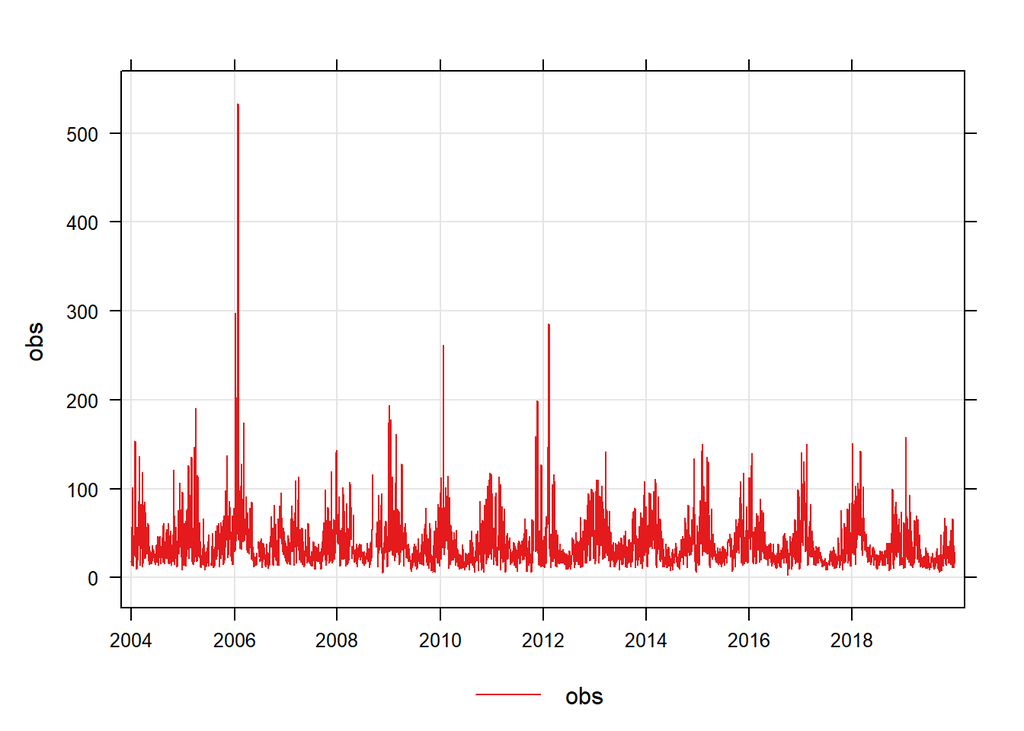

```r
timePlot(Radom, pollutant = "obs", avg.time = "day")
```

## 5.4. Złączenie danych

Otrzymane dane na temat zanieczyszczenia połączyliśmy w sposób analogiczny z danymi dotyczącymi pogody w danym okresie.

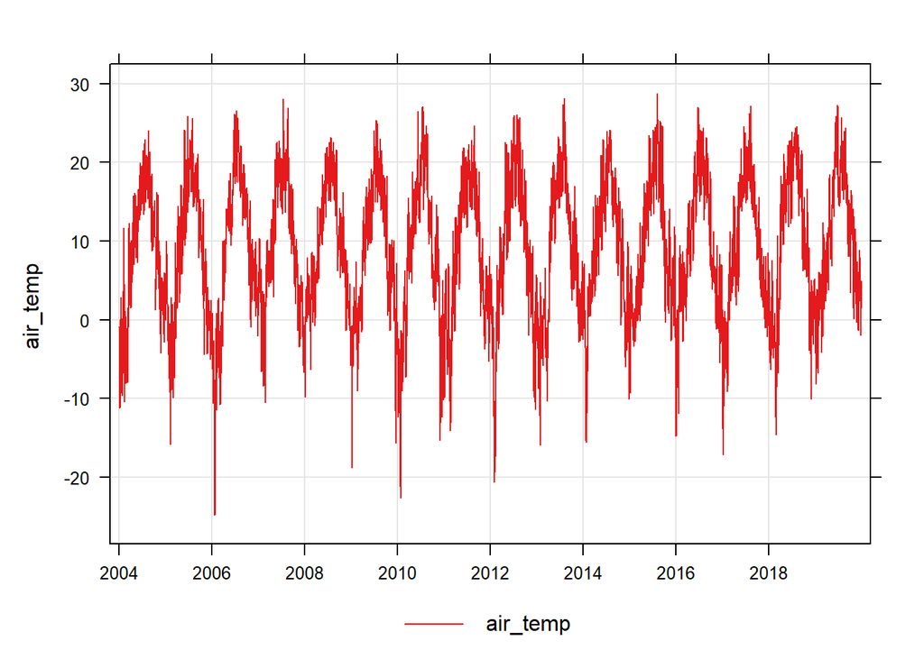

```r
#laczenie
Radom <- left_join(Radom, kozienice, by = "date")
timePlot(Radom, pollutant = "air_temp", avg.time = "day")
```

Jak widzimy na powyższym wykresie rozkład temperatury w danych latach charakteryzuje się identycznym rozkładem. Co prawda widzimy nieznaczne różnice w wartościach maksymalnych bądź minimalnych jednak kształt a co za tym idzie przebieg temperatury w skali roku jest zachowany.

postanowiliśmy “okroić” naszą zmienną wybierając tylko te zmienne, które realnie przydadzą nam się w naszej analizie, uznaliśy że przyśpieszy to przebieg naszej analizy oraz ułatwi nam pracę.

```r
Radom2 <- Radom %>%
  select(date, obs, ws, air_temp, dew_point, atmos_pres, RH, visibility)
```

## 5.5. Uśrednianie danych

Uśrednianie danych było kolejnym etapem naszej analizy który postanowiliśmy wykonać. W tym celu wykonaliśmy poniższy szereg poleceń, który miał za zadanie uśrednić utworzone przez nas modele do zadanych w poleceniu okresów czasowych.

```r
#usrednianie danych
Radom_m <- Radom2 %>%  timeAverage(avg.time = "month")
Radom_m2 <- Radom2 %>%  timeAverage(avg.time = "month")
Radom_m2<- Radom_m2 %>% selectByDate(year= 2004:2019)
Radom_m <- Radom_m %>% selectByDate(year= 2004:2019)
Radom_d <- Radom2 %>%  timeAverage(avg.time = "day")
Radom_w <- Radom2 %>%  timeAverage(avg.time = "week")
```

Po wykonaniu uśredniania zgodnie z powyższymi parametrami nadpiszmy nasze zmienne korzystając z biblioteki tsibble.

```r
Radom_d <- Radom_d %>%
  mutate(date = ymd(date)) %>%
  as_tsibble(index = date)

Radom_m <- Radom_m %>%
  mutate(date = yearmonth(date)) %>%
  as_tsibble(index = date)
```

# 6. Analiza danych

## 6.1. Wykres czasu (time plot)

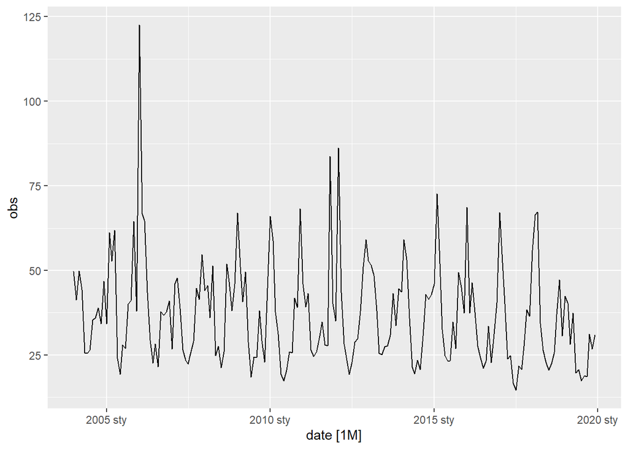

```r
Radom_m %>% autoplot()
```

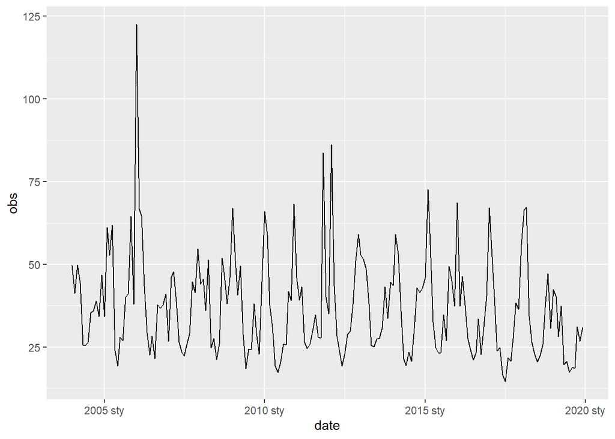

```r
ggplot(data = Radom_m, aes(x= date, y=obs))+
  geom_line()
```

## 6.2. Wykresy sezonowe

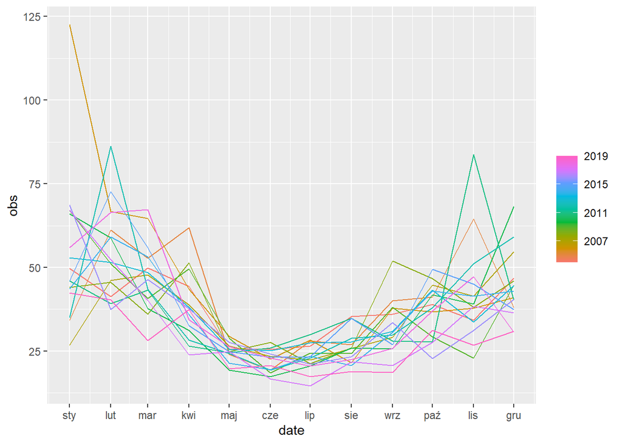

```r
gg_season(Radom_m,obs)
```

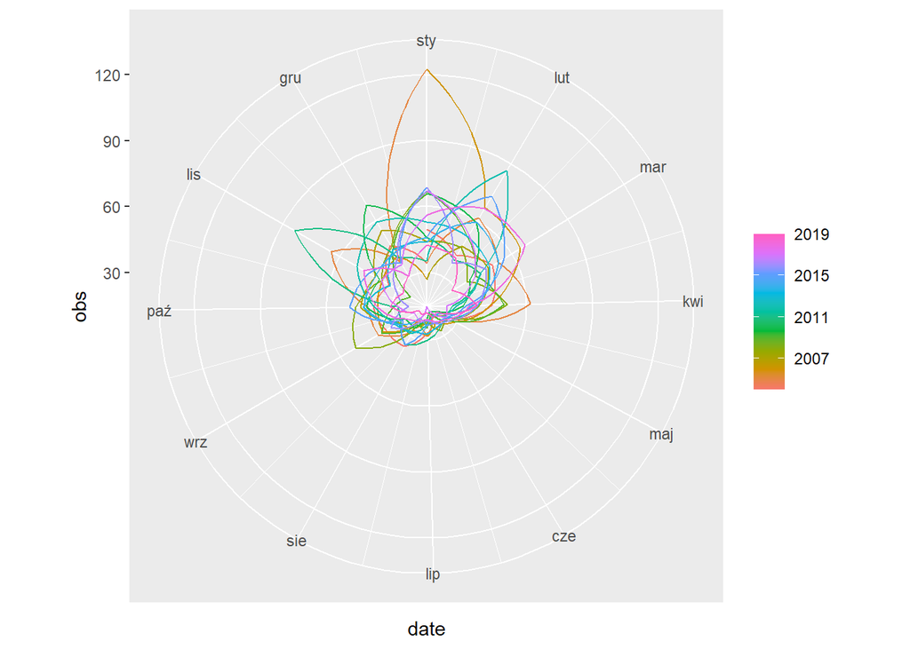

```r
gg_season(Radom_m,obs, polar = T)
```

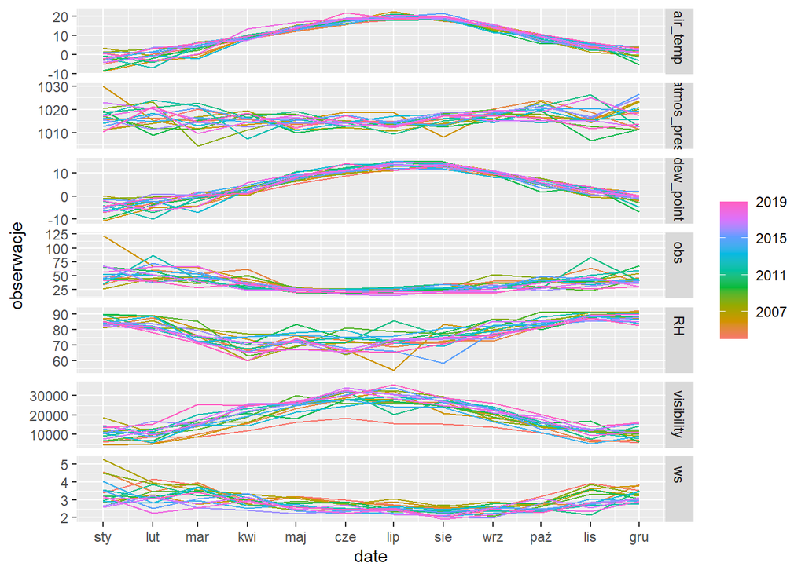

```r
Radom_m %>%
  gather(key = "param", value = "obserwacje", obs:visibility) %>%
  gg_season()
```

## 6.3. Wykresy sezonowych pod serii

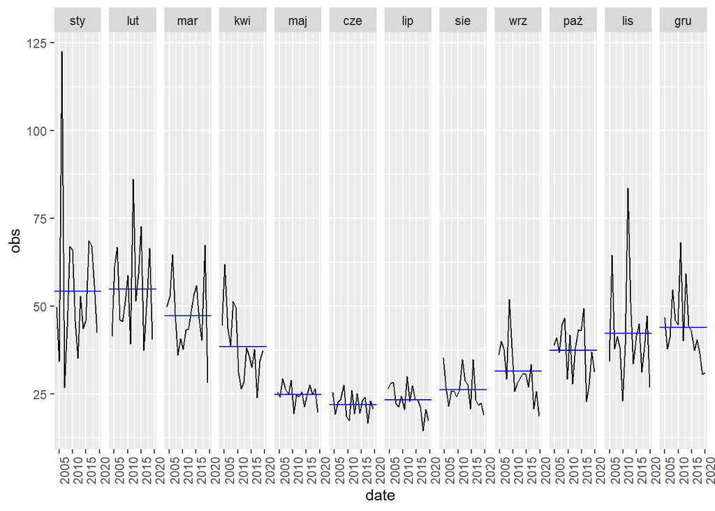

```r
gg_subseries(Radom_m, obs, period = "year")
```

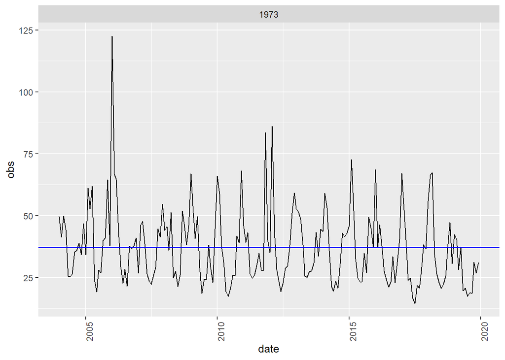

```r
gg_subseries(Radom_m, obs, period = "month")
```

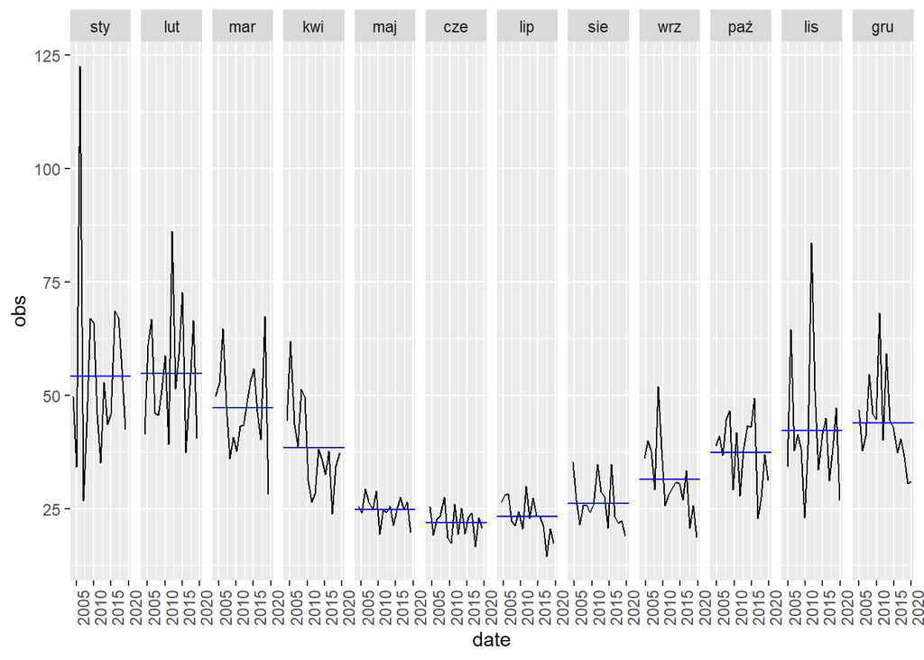

```r
Radom_m %>% gg_subseries()
```

## 6.4. Wykres rozrzutu

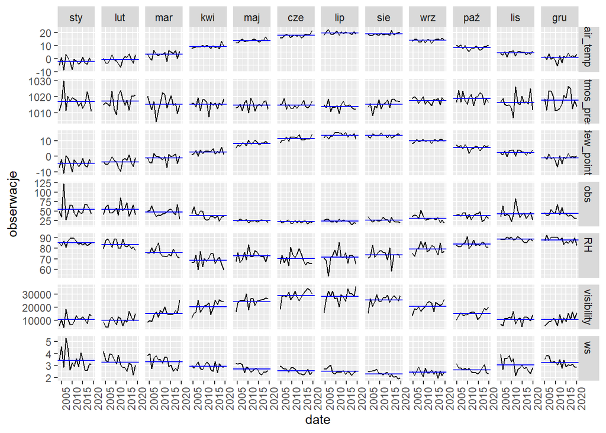

```r
Radom_m %>%
  gather(key = "param", value = "obserwacje", obs:visibility) %>%
  gg_subseries()
```

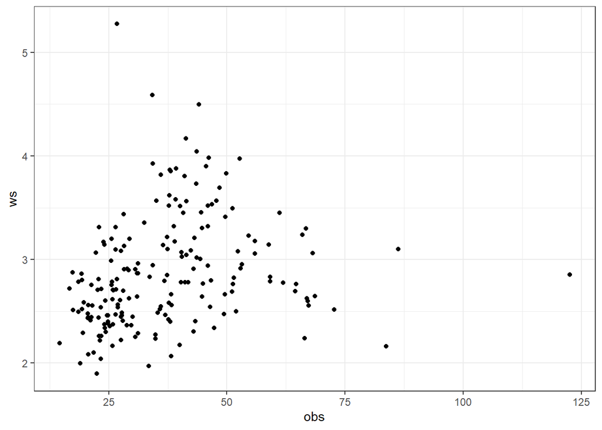

```r
Radom_m %>%
  ggplot(aes(x = obs, y = ws)) +
  geom_point() +
  theme_bw()
```

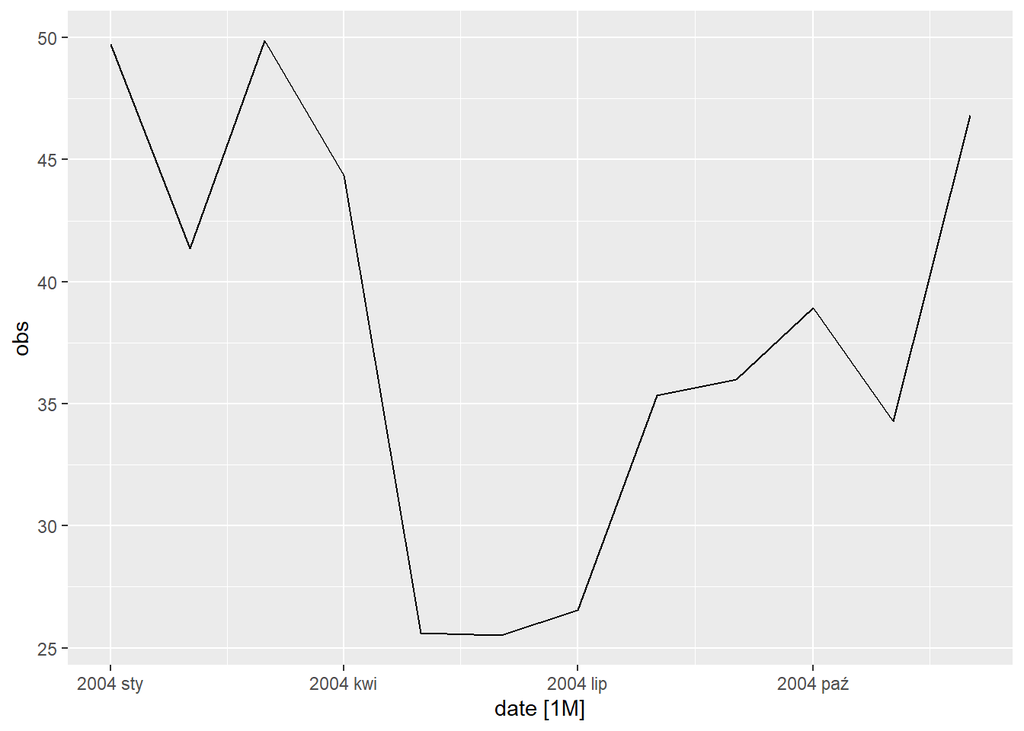

```r
Radom_m %>% filter(year(date)==2004) %>% autoplot(obs)
```

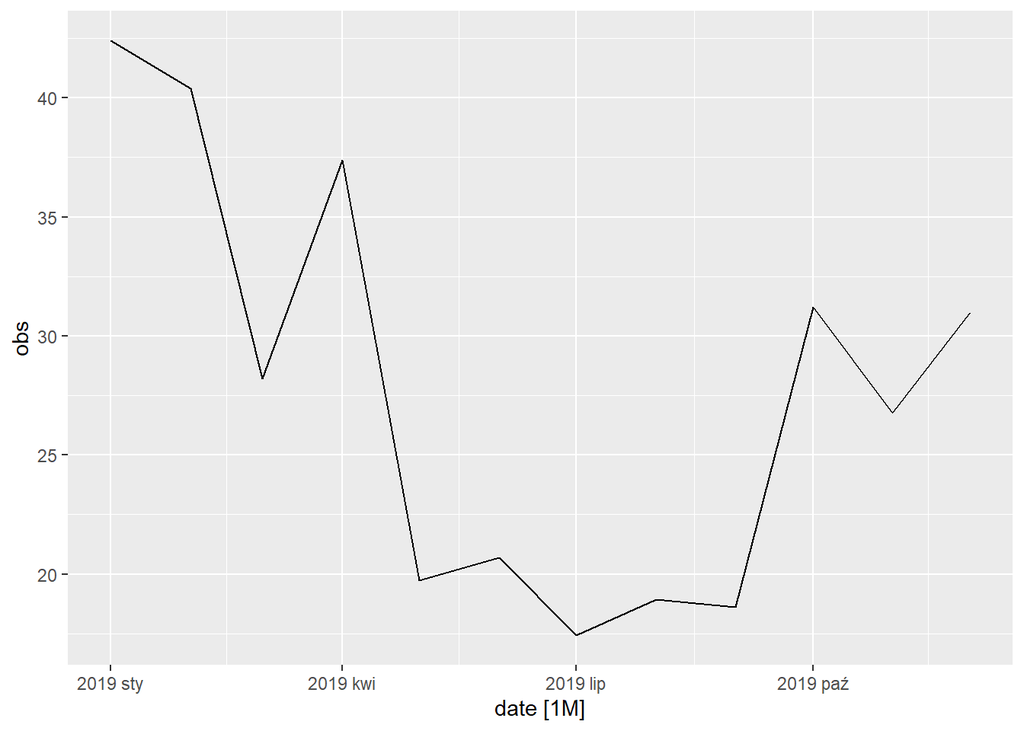

```r
Radom_m %>% filter(year(date)==2019) %>% autoplot(obs)
```

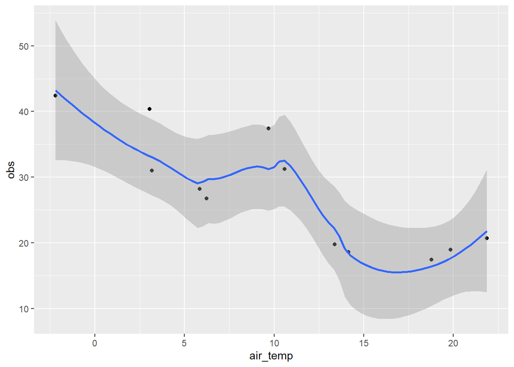

```r
ggplot(data = Radom_m %>% filter(year(date)==2019) %>% as.data.frame(),
       aes(air_temp, obs))+
  geom_point()+
  geom_smooth()
```

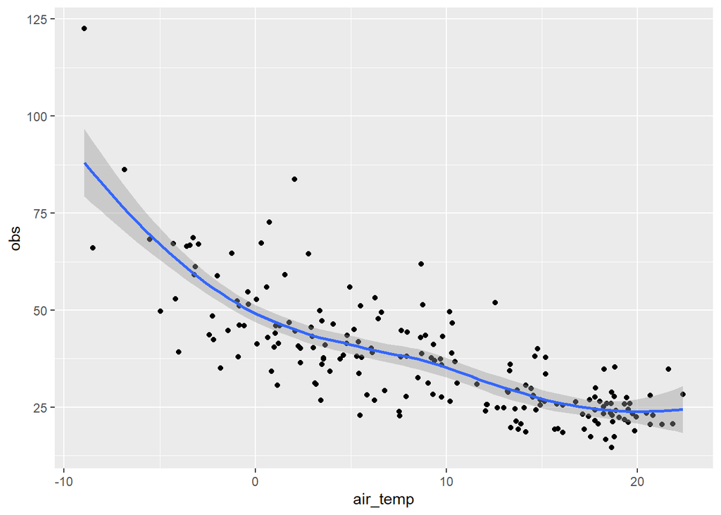

```r
ggplot(data = Radom_m %>% as.data.frame(),
       aes(air_temp, obs))+
  geom_point()+
  geom_smooth()
```

```r
cor(Radom_m["obs"], Radom_m["air_temp"], method ="p")
```

```
##       air_temp
## obs -0.7694849
```

## 6.5. Wykres opóźnień

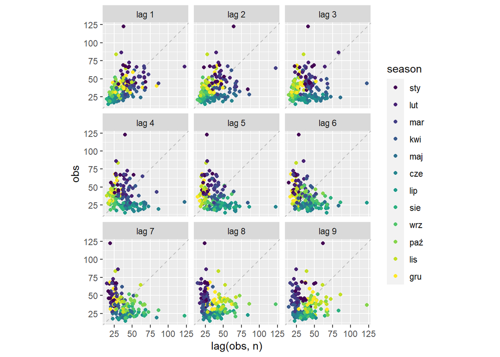

```r
Radom_m %>% gg_lag(obs, geom="point")
```

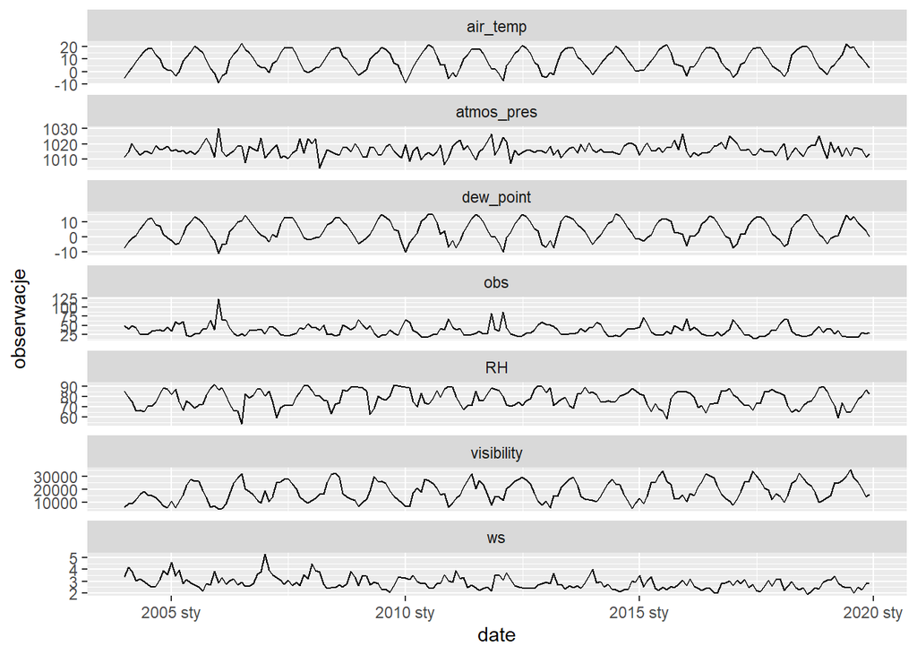

```r
Radom_m %>%
  gather(key = "param", value = "obserwacje", obs:visibility) %>%
  ggplot(aes(x = date, y = obserwacje)) +
  geom_line() +
  facet_wrap(~param, scales = "free_y", ncol = 1)
```

## 6.6. Autokorelacja

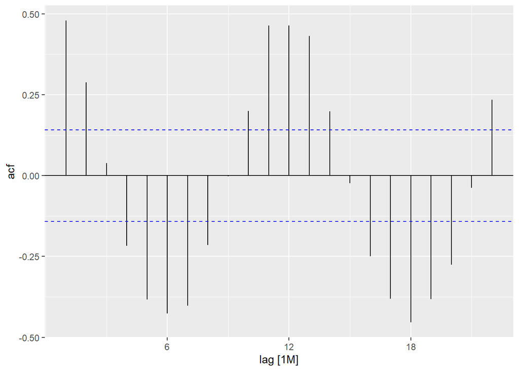

```r
#autokorelacja
Radom_m %>% ACF(obs) %>% autoplot()
```

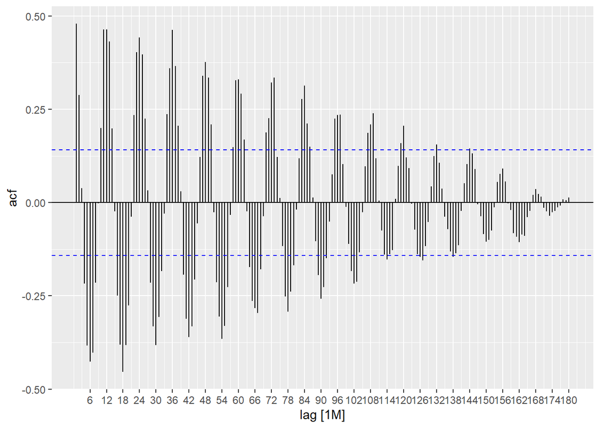

```r
Radom_m %>% ACF(obs, lag_max= 180) %>% autoplot()
```

## 6.7. Biały szum

```r
#seria nie jest bialym szumem poniewaz skoki znajduja sie nad niebieska linia
year(Radom_m$date)
```

```
##   [1] 2004 2004 2004 2004 2004 2004 2004 2004 2004 2004 2004 2004 2005 2005 2005
##  [16] 2005 2005 2005 2005 2005 2005 2005 2005 2005 2006 2006 2006 2006 2006 2006
##  [31] 2006 2006 2006 2006 2006 2006 2007 2007 2007 2007 2007 2007 2007 2007 2007
##  [46] 2007 2007 2007 2008 2008 2008 2008 2008 2008 2008 2008 2008 2008 2008 2008
##  [61] 2009 2009 2009 2009 2009 2009 2009 2009 2009 2009 2009 2009 2010 2010 2010
##  [76] 2010 2010 2010 2010 2010 2010 2010 2010 2010 2011 2011 2011 2011 2011 2011
##  [91] 2011 2011 2011 2011 2011 2011 2012 2012 2012 2012 2012 2012 2012 2012 2012
## [106] 2012 2012 2012 2013 2013 2013 2013 2013 2013 2013 2013 2013 2013 2013 2013
## [121] 2014 2014 2014 2014 2014 2014 2014 2014 2014 2014 2014 2014 2015 2015 2015
## [136] 2015 2015 2015 2015 2015 2015 2015 2015 2015 2016 2016 2016 2016 2016 2016
## [151] 2016 2016 2016 2016 2016 2016 2017 2017 2017 2017 2017 2017 2017 2017 2017
## [166] 2017 2017 2017 2018 2018 2018 2018 2018 2018 2018 2018 2018 2018 2018 2018
## [181] 2019 2019 2019 2019 2019 2019 2019 2019 2019 2019 2019 2019
```

```r
Radom_m %>% features(obs, list(mean = mean)) %>%
  arrange(mean)
```

```
## # A tibble: 1 × 1
##    mean
##   <dbl>
## 1  37.2
```

## 6.8. Proste statystyki

```r
# 4.1. Proste statystyki --------------------------------------------------

# Wiele statystyk z nazwą (list)
Radom_m %>%
  features(obs,
           list(mean = mean,
                median = median)) %>% #milego dnia
  arrange(desc(mean))
```

```
## # A tibble: 1 × 2
##    mean median
##   <dbl>  <dbl>
## 1  37.2   35.2
```

```r
# funkcja z dodotkowymi parametrami
Radom_m %>%
  features(obs, quantile, probs = seq(0, 1, by = 0.25))
```

```
## # A tibble: 1 × 5
##    `0%` `25%` `50%` `75%` `100%`
##   <dbl> <dbl> <dbl> <dbl>  <dbl>
## 1  14.6  25.7  35.2  44.7   123.
```

## 6.9. Funkcje ACF

```r
# 4.2. Funckje ACF --------------------------------------------------------

Radom_m %>%
  features(obs, feat_acf) # domyślnie lag = 10
```

```
## # A tibble: 1 × 7
##    acf1 acf10 diff1_acf1 diff1_acf10 diff2_acf1 diff2_acf10 season_acf1
##   <dbl> <dbl>      <dbl>       <dbl>      <dbl>       <dbl>       <dbl>
## 1 0.479 0.938     -0.316       0.157     -0.639       0.469       0.463
```

```r
# Funkcja zwrac 6 lub 7 wyników
# - wartość autokorelacji dla pierwotnych danych;
# - suma kwadratu pierwszych dziesięciu współ. autokorelacji z pierwotnych
# danych;
# - pierwszy współ. autokorelacji z różnicowanych danych (druga minus pierwsza,
# trzecia minu druga itd.);
# - suma kwadratu pierwszych dziesięciu współ. autokorelacji z różnicowanych
# danych
# - różnice sezonowe pomiędzy kolejnymi zmiennymi (np, różnice miedzy kolejnymi
# stycznniami, itd..)
# - pierwszy współ. autokorelacji z podwójnie zróżnicowanych danych;
# - suma kwadratu pierwszych dziesięciu współ. autokorelacji z podwójnie
# zróżnicowanych danych;
# - W przypadku danych sezonowych zwracany jest również współczynnik
# autokorelacji przy pierwszym sezonowym opóźnieniu
```

## 6.10. Funkcje STL

```r
# 4.3. Funkcje STL --------------------------------------------------------

#  obliczenia siły trendu i sezonowości

Radom_m %>%
  features(obs, feat_stl) -> sila_kompnentow_obs

Radom_m %>%
  features(air_temp, feat_stl) -> sila_kompnentow_air_temp

Radom_m %>%
  features(dew_point, feat_stl) -> sila_kompnentow_dew_point

Radom_m %>%
  features(atmos_pres, feat_stl) -> sila_kompnentow_atmos_pres

 Radom_m %>%
  features(RH, feat_stl) -> sila_kompnentow_RM

Radom_m %>%
  features(visibility, feat_stl) -> sila_kompnentow_visibility
```

```r
sila_kompnentow_obs
```

```
## # A tibble: 1 × 9
##   trend_strength seasonal_strength_… seasonal_peak_y… seasonal_trough… spikiness
##            <dbl>               <dbl>            <dbl>            <dbl>     <dbl>
## 1          0.213               0.634                2                6      1.82
## # … with 4 more variables: linearity <dbl>, curvature <dbl>, stl_e_acf1 <dbl>,
## #   stl_e_acf10 <dbl>
```

```r
sila_kompnentow_air_temp
```

```
## # A tibble: 1 × 9
##   trend_strength seasonal_strength_… seasonal_peak_y… seasonal_trough… spikiness
##            <dbl>               <dbl>            <dbl>            <dbl>     <dbl>
## 1          0.214               0.954                7                1  0.000672
## # … with 4 more variables: linearity <dbl>, curvature <dbl>, stl_e_acf1 <dbl>,
## #   stl_e_acf10 <dbl>
```

```r
sila_kompnentow_dew_point
```

```
## # A tibble: 1 × 9
##   trend_strength seasonal_strength_… seasonal_peak_y… seasonal_trough… spikiness
##            <dbl>               <dbl>            <dbl>            <dbl>     <dbl>
## 1          0.162               0.937                7                1  0.000638
## # … with 4 more variables: linearity <dbl>, curvature <dbl>, stl_e_acf1 <dbl>,
## #   stl_e_acf10 <dbl>
```

```r
sila_kompnentow_atmos_pres
```

```
## # A tibble: 1 × 9
##   trend_strength seasonal_strength_… seasonal_peak_y… seasonal_trough… spikiness
##            <dbl>               <dbl>            <dbl>            <dbl>     <dbl>
## 1          0.122               0.246               10                7   0.00839
## # … with 4 more variables: linearity <dbl>, curvature <dbl>, stl_e_acf1 <dbl>,
## #   stl_e_acf10 <dbl>
```

```r
sila_kompnentow_RM
```

```
## # A tibble: 1 × 9
##   trend_strength seasonal_strength_… seasonal_peak_y… seasonal_trough… spikiness
##            <dbl>               <dbl>            <dbl>            <dbl>     <dbl>
## 1          0.285               0.810                0                4    0.0174
## # … with 4 more variables: linearity <dbl>, curvature <dbl>, stl_e_acf1 <dbl>,
## #   stl_e_acf10 <dbl>
```

```r
sila_kompnentow_visibility
```

```
## # A tibble: 1 × 9
##   trend_strength seasonal_strength_… seasonal_peak_y… seasonal_trough… spikiness
##            <dbl>               <dbl>            <dbl>            <dbl>     <dbl>
## 1          0.542               0.894                6               11    2.14e9
## # … with 4 more variables: linearity <dbl>, curvature <dbl>, stl_e_acf1 <dbl>,
## #   stl_e_acf10 <dbl>
```